# School of Information Technology - Orientation Survey 2019-20 [STATISTICS]

Chethana W

26/11/2019

## About

This page contains graphical interpretations of the **2019-20 Orientation survey** results. Online survey can be found in this [link](http://esg.apps01.yorku.ca/machform/view.php?id=158862) .

Current Data size: 115 Students [92 Students (Paper submissions) & 23 Students (Online submission)]

## Q1: Question 1

You are a  
□ Domestic  
□ International

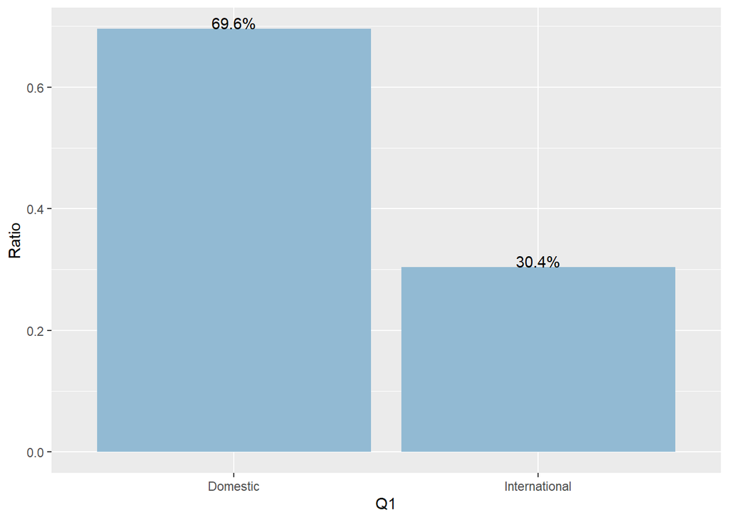

## Q2: Question 2

Which ITEC program are you pursuing?  
A □ BA-ITEC  
B □ BCom-ITEC  
C □ Honours Major or Double Major  
D □ Honours Minor  
E □ Ordinary BA  
F □ Other/Undecided  
G □ I don’t know

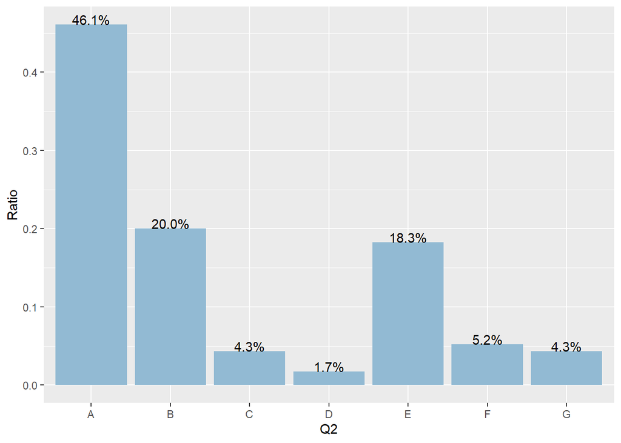

## Q3: Question 3

Are you currently employed?  
□ Yes, full-time  
□ Yes, part-time  
□ Not employed

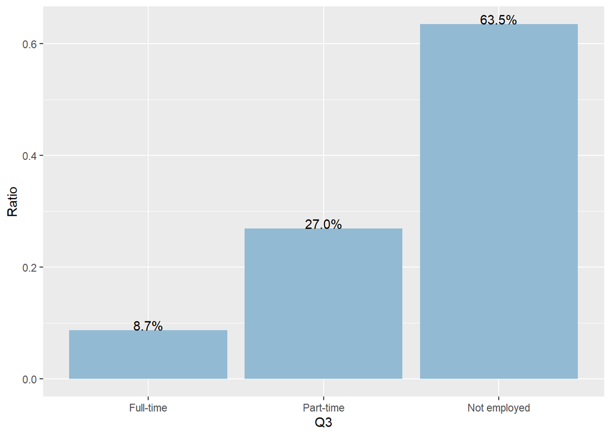

## Q4: Question 4

Did you know of the School of Information Technology(ITEC) before coming to York?  
□ Yes  
□ No

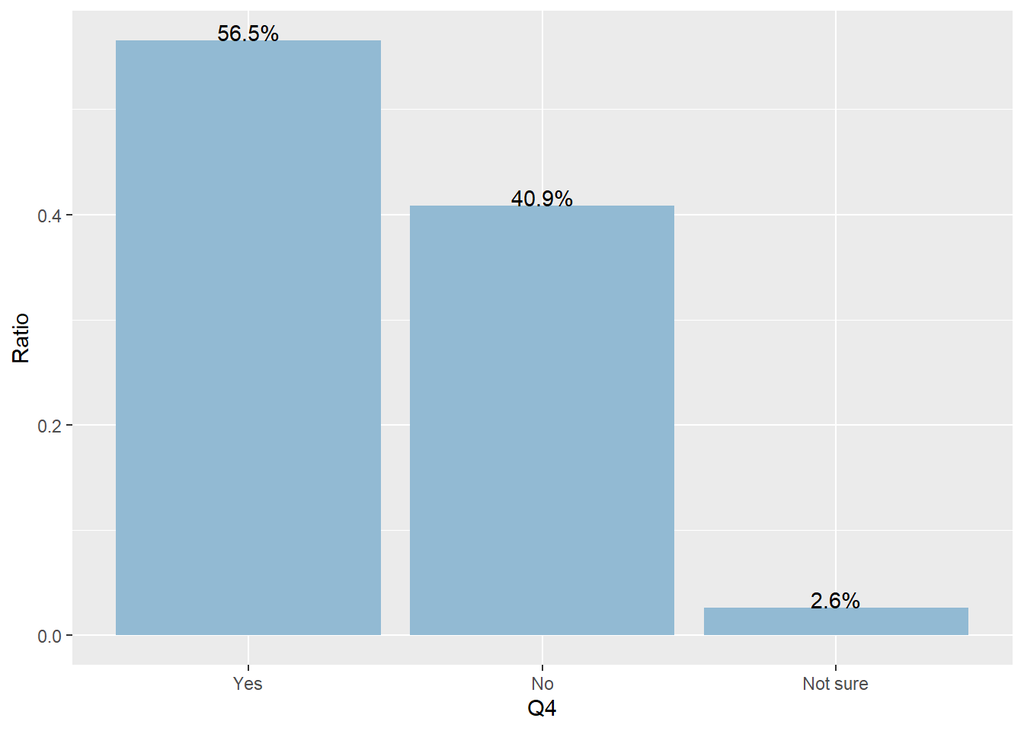

## Q5: Question 5

If yes, where did you first learn about ITEC from(select all the apply)?  
A □ Web  
B □ Friends/parents/relatives - word of mouth  
C □ Recruitment agency  
D □ High-school  
E □ University fair, York open-house or similar event  
F □ Other

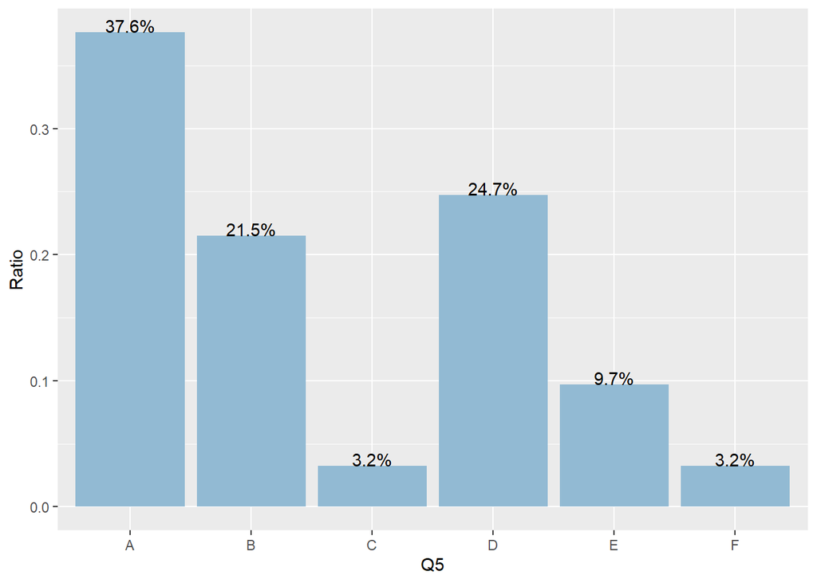

## Q6: Question 6

What choice was ITEC in your application?  
□ My 1st choice  
□ My 2nd choice  
□ My 3rd choice  
□ My 4th choice  
□ None-ITEC was suggested for me after I came to York Univeristy

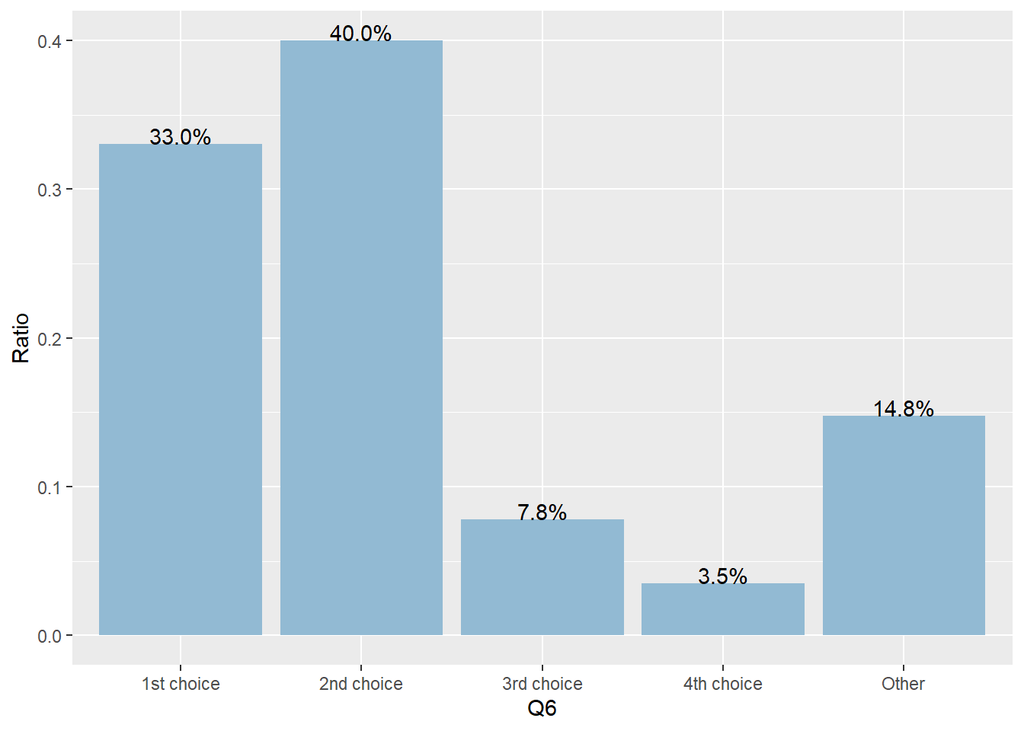

## Q7: Question 7

Did you also apply to Computer Science at York Uinversity?  
A □ Yes and I am still interested to go there  
B □ Yes, but I am not interested to go there anymore  
C □ No, but I could consider switching  
D □ No and I am not interested in switching

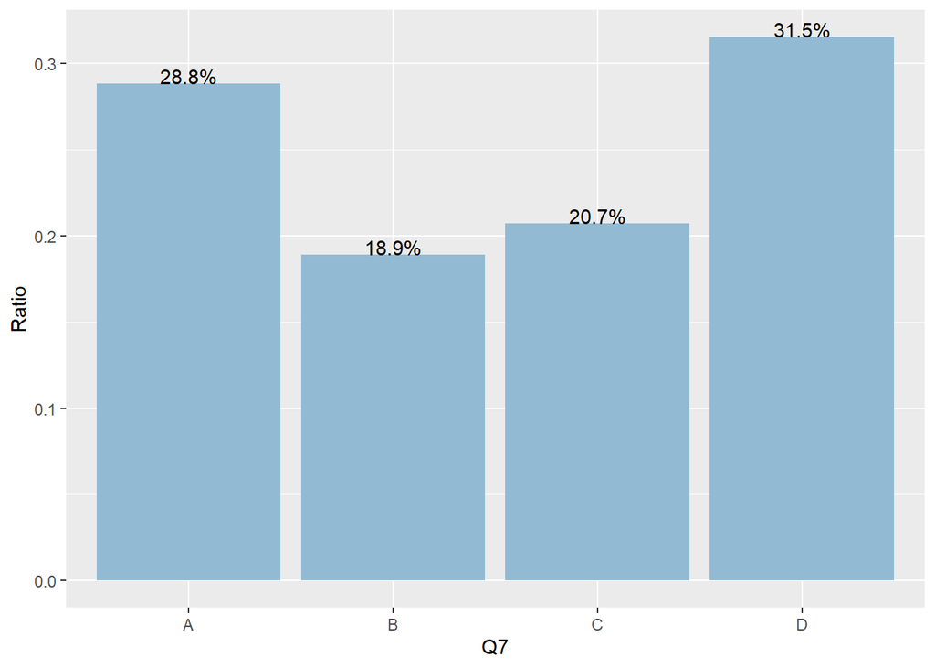

## Q8: Question 8

Which of the two are you most interested in?  
□ Mostly computers and software  
□ Mostly businesses and organizations  
□ Both equally

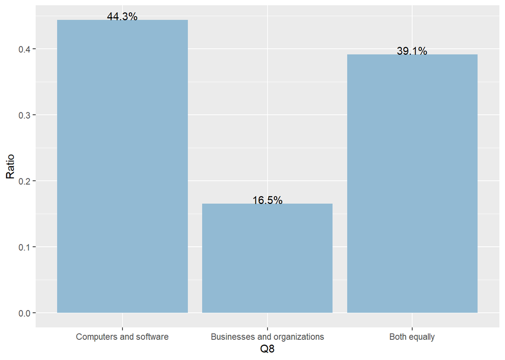

## Q9: Question 9

Which of the following topics of study fascinate you the most? Pick at most three (3)  
A □ Software Development  
B □ Computer Hardware and Devices  
C □ Complex Business Systems  
D □ Data Analysis and Databases  
E □ Artificial Intelligence  
F □ Information Technology Management  
G □ Graphics and Video Game Design  
H □ Hacking and Security  
I □ Networks and their Design  
J □ Other

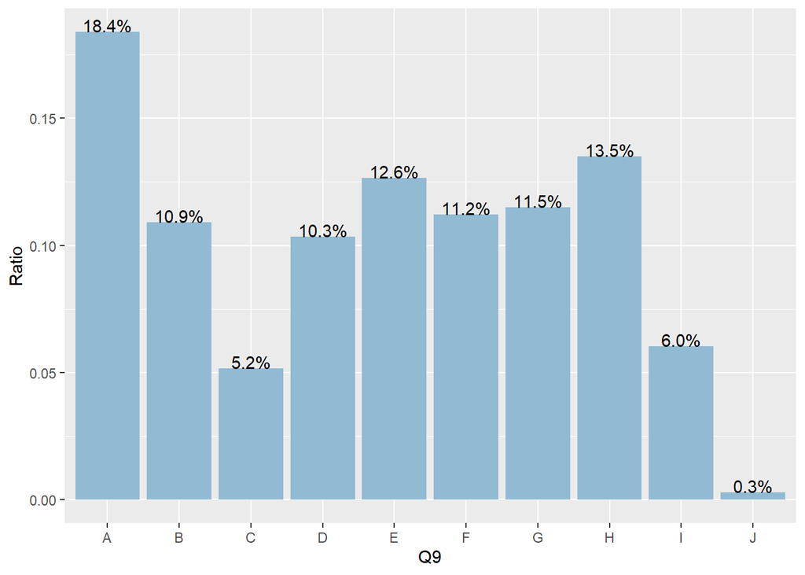

*Students with interest in computer science*

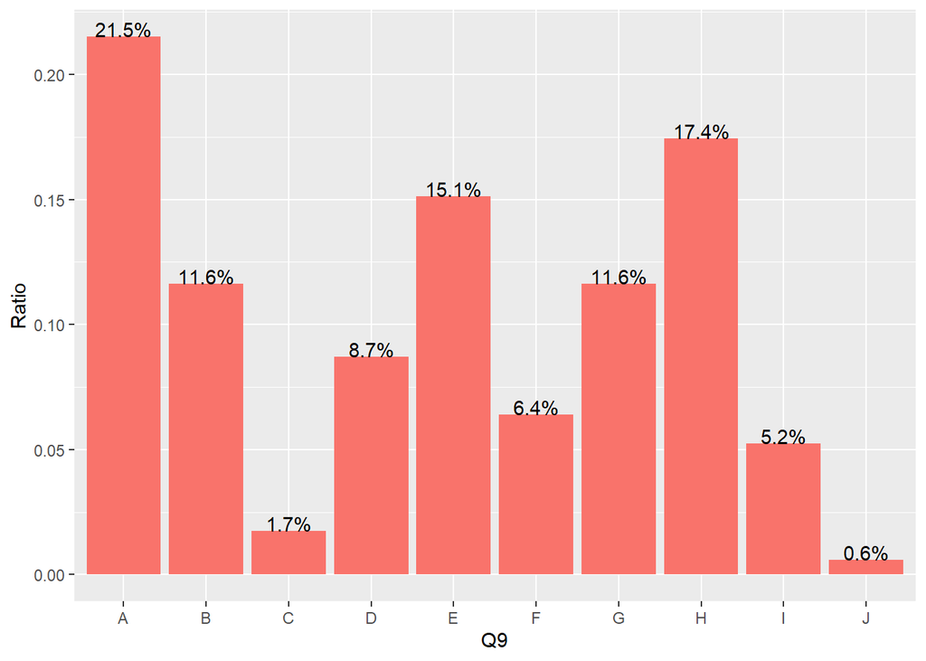

*Students with interest in ITEC*

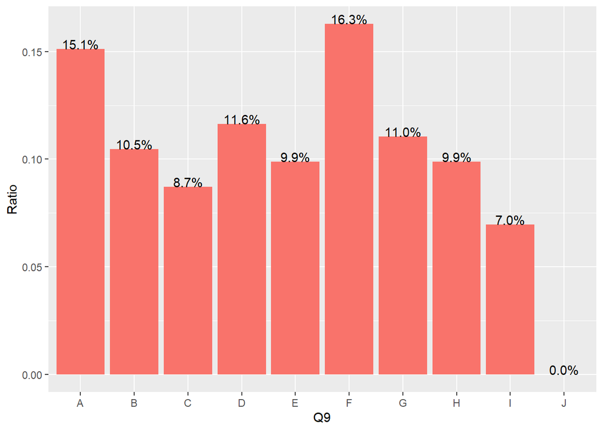

*Students who are more interested in computers and software*

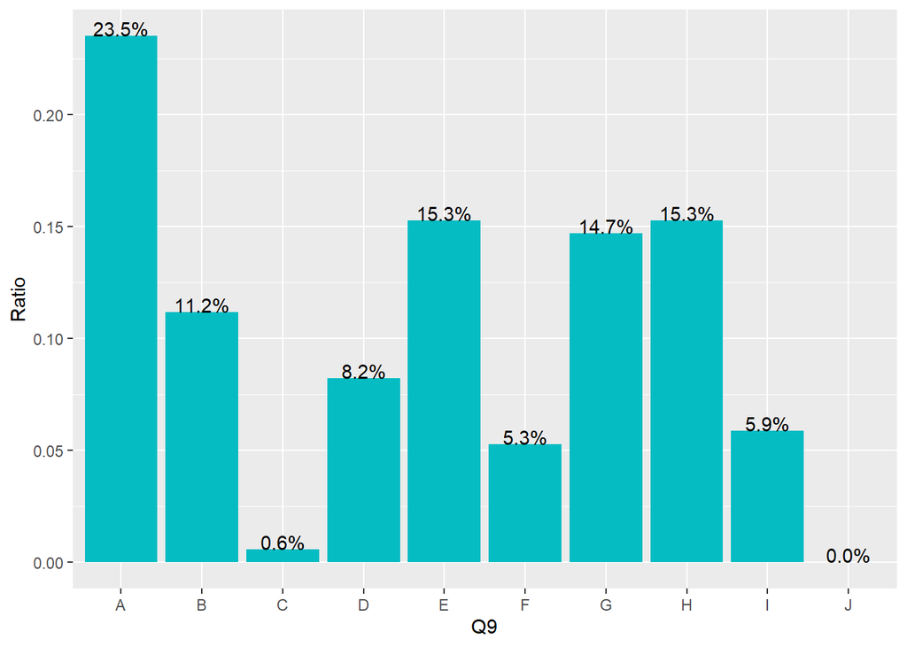

*Students who are more interested in businesses and organizations*

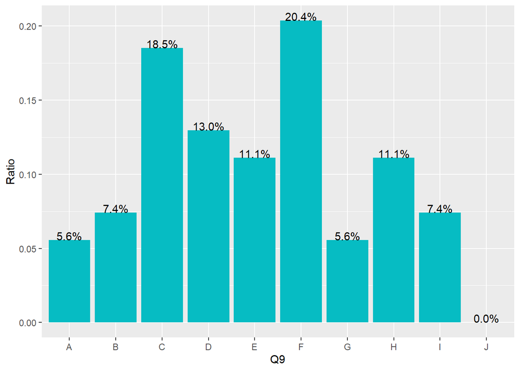

*Students who are more interested in all (computers, software, businesses, and organizations)*

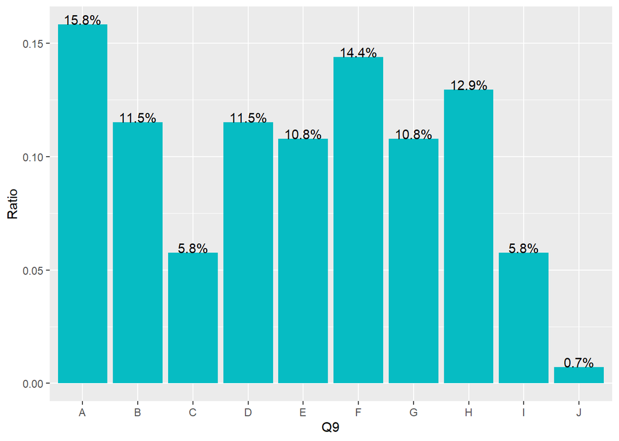

## Q10: Question 10

Which are your preferred days to have classes?  
□ Monday  
□ Tuesday  
□ Wednesday  
□ Thursday  
□ Friday  
□ Saturday  
□ Sunday

*MOST POPULAR DAYS IN A WEEK FOR CLASSES*

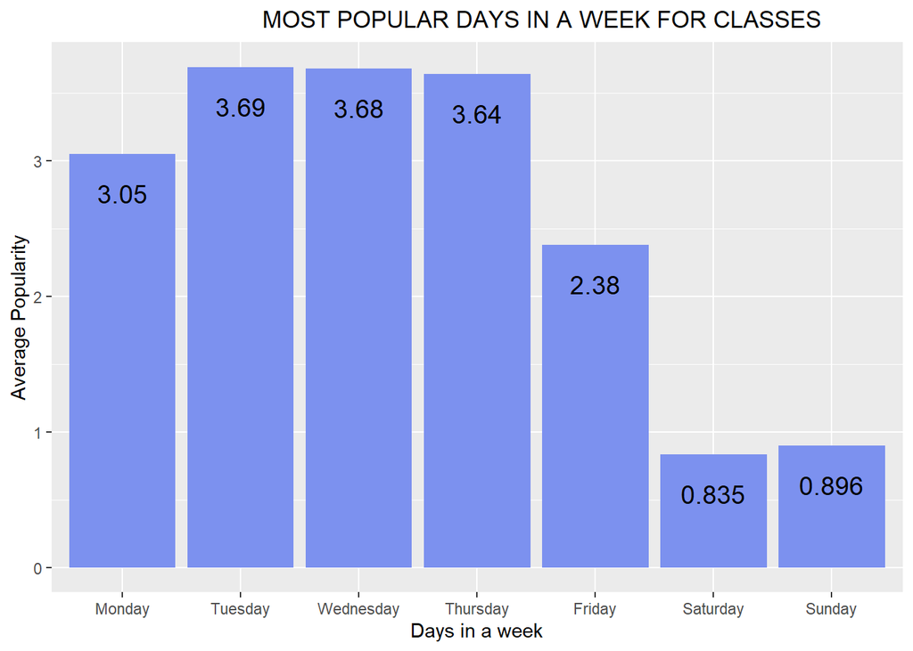

*POPULAR AVERAGE DAYS IN A WEEK FOR CLASSES*

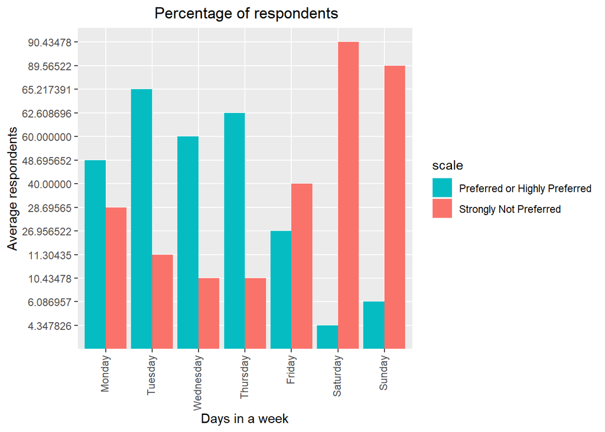

## Q11: Question 11

Which times are your favorite ones to have classes?  
□ Morning(8:30am-11:30am)  
□ Early Afternoon(11:30am-2:30pm)  
□ Late Afternoon(2:30pm-5:30pm)  
□ Early Evening(4:00pm-7:00pm)  
□ Late Evening(7:00pm-10:00pm)

*MOST POPULAR TIMES IN A DAY TO HAVE CLASS*

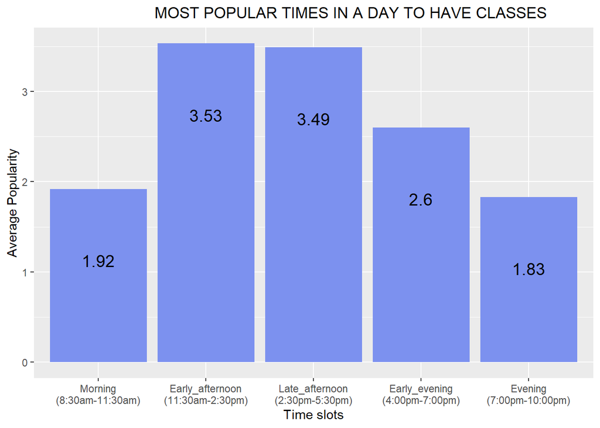

*POPULAR AVERAGE TIMES IN A DAY TO HAVE CLASS*

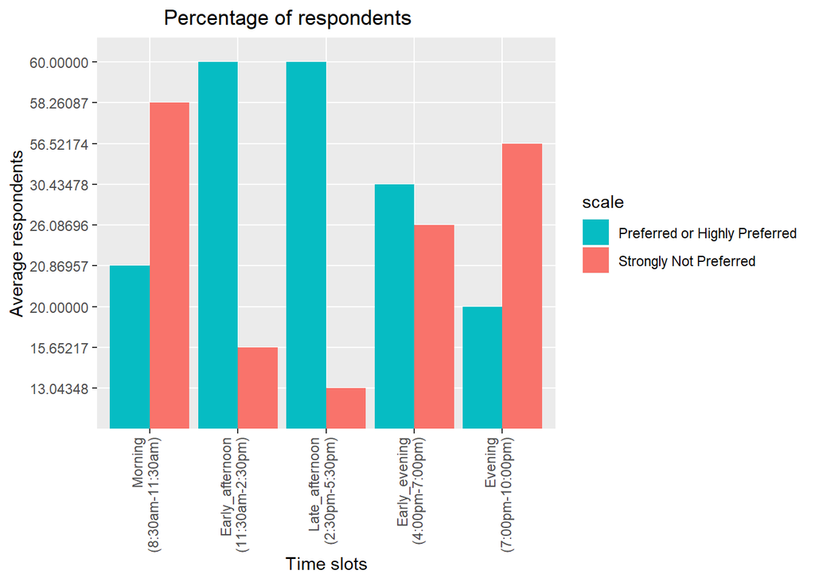